# Flexible Damage Functions

Author

James Rising, Sebastian Cadavid Sanchez, Climate Impact Lab

Published

April 30, 2026

## 0.1 Agriculture: Rice Country

Flexible damage function parameters at the Country level.

**Change in rice yields (log change in yields) under full adaptation**

**Outcome units:** `physical` — log change in rice yield (population-weighted to country)

$$D_{it} = (\alpha_i T_t + \beta_i T_t^2) \cdot Y_{it}^{\gamma}$$

where $\gamma$ is the income elasticity (fitted globally), $\alpha_i$ is the linear coefficient, and $\beta_i$ is the quadratic coefficient.

# 1 Global Estimation

## 1.1 Income Elasticity Estimation

The income elasticity $\gamma$ is estimated using a fixed-effects regression:

$$y_{it} = \gamma \cdot \log(Y_{it}) + \mu_{g(i,T)} + \nu_t + \varepsilon_{it}$$

where $\mu_{g(i,T)}$ are region-by-temperature-bin fixed effects and $\nu_t$ are year fixed effects.

Table 1: Income Elasticity (Gamma) Estimation Results

| Statistic | Value |
| --- | --- |
| Income elasticity ($\gamma$) | 0.4893 |
| Standard error | 1.26e-02 |
| 95% CI | [0.4646, 0.5141] |
| R-squared | 0.5600 |
| Observations | 2,911,902 |
| Regions | 140 |
| Gamma quantiles | 19 |

# 2 Parameter Distributions

## 2.1 8-Panel Summary

Row 1: gamma, alpha, beta, rsqr1. Row 2: rho, zeta, eta, rsqr2.

```
Using median gamma: 0.489336, 140 rows (of 2,660 total)
```

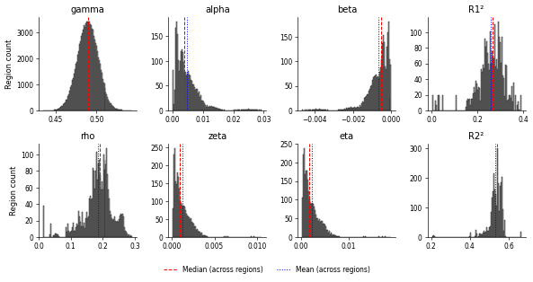

Figure 1: Distribution of Regional Parameters

## 2.2 Projection Equation and Parameter Definitions

The estimated parameters are used to project damages via Monte Carlo sampling:

$$D_{it}^k = (\hat{\alpha}_{ik} T_t + \hat{\beta}_{ik} T_t^2) Y_{it}^{\hat{\gamma}_k} + \hat{\theta}_{ik} T_t Y_{it}^{\hat{\gamma}_k} + \hat{\phi}_{it}^k$$

where $k$ indexes the Monte Carlo draw. The parameters in each row of the output CSV control distinct components of this equation:

- **gamma**: income elasticity $\hat{\gamma}_k$, one of 19 quantile values drawn from $N(\hat{\gamma}, SE(\hat{\gamma}))$
- **alpha, beta**: linear and quadratic temperature coefficients; $\hat{\alpha}_{ik}$ and $\hat{\beta}_{ik}$ are drawn from the joint normal defined by the VCV below
- **sigma11, sigma12, sigma22**: variance-covariance matrix of $(\alpha, \beta)$, used for joint uncertainty sampling
- **rho**: correlation between regional and global polynomial residuals $\rho_i$, used to maintain spatial covariance across regions in Monte Carlo draws
- **zeta**: temperature-dependent error scale $\zeta_{ik}$; the run-specific error term $\hat{\theta}_{ik}$ is drawn from $N(0, \zeta_{ik})$
- **eta**: residual noise standard deviation $\eta_{ik}$; the annual noise $\hat{\phi}_{it}^k$ is drawn from $N(0, \eta_{ik})$
- **rsqr1, rsqr2**: polynomial fit quality and error model fit, respectively

## 2.3 Summary Statistics

Table 2: Regional Parameter Summary

| Parameter | Mean | Median | Std | Min | Max | N |
| --- | --- | --- | --- | --- | --- | --- |
| alpha | 0.004681 | 0.003616 | 0.003902 | 2.828e-05 | 0.02577 | 140 |
| beta | -0.0006834 | -0.0005046 | 0.000606 | -0.003957 | 0 | 140 |
| rho | 0.1854 | 0.1898 | 0.04665 | 0.01424 | 0.2782 | 140 |
| zeta | 0.001294 | 0.0009785 | 0.00117 | 0.000174 | 0.009476 | 140 |
| eta | 0.002383 | 0.001778 | 0.002188 | 0.0003922 | 0.01713 | 140 |
| rsqr1 | 0.2568 | 0.265 | 0.06596 | 0.0005326 | 0.3888 | 140 |
| rsqr2 | 0.5322 | 0.5397 | 0.04181 | 0.2129 | 0.6619 | 140 |

# 3 Spaghetti Curves

Regional damage function curves showing D(T) = αT + βT² for sampled regions.

[interactive chart not shown]

Figure 2: Regional Damage Functions

# 4 Zero Crossings

The zero crossing (extremum) of the parabola occurs at $T^* = -\alpha / (2\beta)$.

Table 3: Zero Crossing Statistics

| Category | Count | Percentage |
| --- | --- | --- |
| β = 0 (no crossing) | 2 | 1.4% |
| T > 20°C (beyond graph) | 0 | 0.0% |
| T < 0°C (negative crossing) | 0 | 0.0% |
| Valid crossings (0-20°C) | 138 | 98.6% |

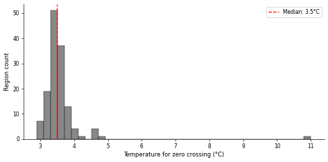

Figure 3: Distribution of Zero Crossing Temperatures

# 5 Slope Analysis

Maximum slope between 0 and 10°C: $\frac{dM}{dT} = \alpha + 2\beta T$

The maximum occurs at either T=0 or T=10 (endpoints of interval).

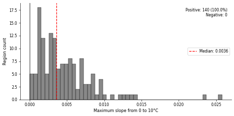

Figure 4: Distribution of Maximum Slopes (0-10°C)

*Convexity analysis omitted (beta constraint active).*

# 6 R-squared Analysis

## 6.1 Polynomial Fit Quality (rsqr1)

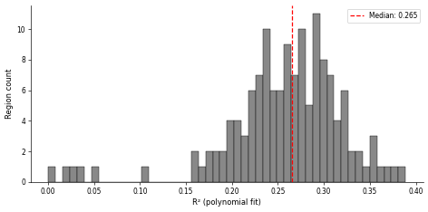

Figure 5: Regional Fit Quality (R-squared)

## 6.2 Error Model R-squared (rsqr2) Quantiles

Table 4: rsqr2 Quantiles

| 0% (Min) | 25% | 50% (Median) | 75% | 100% (Max) |
| --- | --- | --- | --- | --- |
| 0.2129 | 0.5207 | 0.5397 | 0.5551 | 0.6619 |

# 7 Modelled Variance

Modelled variance statistic: $1 - \frac{\sum_i \eta_i^2}{\sum_i D_i^2}$

Table 5: Modelled Variance Statistics

| Statistic | Value |
| --- | --- |
| Modelled variance | 0.8976 |
| Sum(η²) | 0.0015 |
| Sum(D²) at T=3.0°C | 0.0143 |
| N regions | 140 |

# 8 Best- and Worst-Fitting Regions

The 3 worst- and 3 best-fitting regions by R-squared, with raw simulation data overlaid on the fitted polynomial curve. **Red rows = worst fits**, **green rows = best fits**.

Table 6: Best- and worst-fitting regions

Top 3 best fit (R²) Top 3 worst fit (R²)

[output not shown]

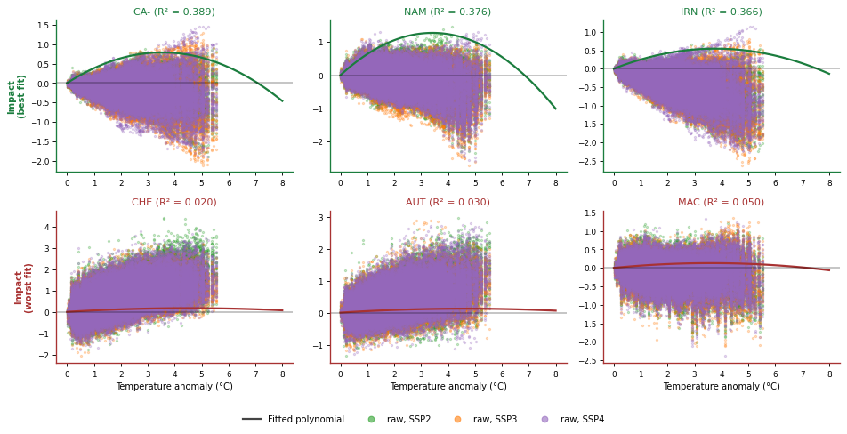

# 9 Regional Parameter Maps

Maps of key parameters at the **country** level. Red = negative (damage increases with T), Blue = positive.

## 9.1 Alpha (Linear Coefficient)

Alpha ($\alpha$) represents the linear sensitivity to temperature. Regions with negative alpha experience damage that increases with the first degree of warming.

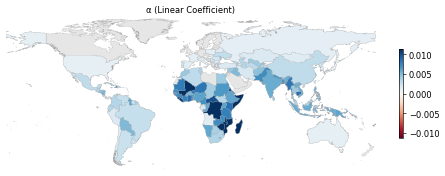

Figure 7: α (linear coefficient)

## 9.2 Beta (Quadratic Coefficient)

Beta ($\beta$) represents the curvature of the damage function.

The concavity ($\beta \leq 0$) constraint is enforced for this sector, meaning optimal temperature exists, damages accelerate beyond it.

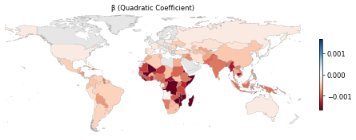

Figure 8: β (quadratic coefficient)

## 9.3 R-squared (Fit Quality)

$R^2$ measures the polynomial fit quality. Higher values indicate that the quadratic form captures more of the variance in the data.

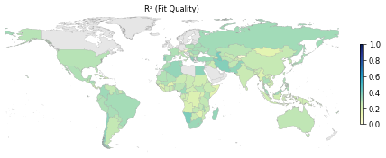

Figure 9: R² (stage 1 fit quality)

# 10 F2: Flex vs Raw Comparison

Comparison of flexible damage function predictions against raw simulation means.

For each scenario (RCP × SSP × Model), we compute at the final year:

- **Flex predicted**: $(\alpha \cdot T + \beta \cdot T^2) \cdot Y^\gamma$
- **Raw actual**: The outcome variable (y) from the source data

**Year 2098**: 1,457,280 rows

**rcp45**

**SSP2**

**high**

**Correlation:** -0.1680 | **RMSE:** 1.759805 | **Sign agreement:** 15.7%

[interactive chart not shown]

Top 5 best predicted Top 5 worst predicted

Year 2098 · T<sub>mean</sub> across these regions: 1.94°C

| Region | Raw | Flex | Residual |
| --- | --- | --- | --- |
| KGZ | -0.0827 | 0.011 | 0.0937 |
| JPN | 0.177 | 0.406 | 0.229 |
| MAC | -0.174 | 0.112 | 0.286 |
| AUT | 0.457 | 0.11 | -0.346 |
| BRN | -0.162 | 0.206 | 0.368 |
| ZWE | -0.154 | 5.45 | 5.61 |
| LBR | -0.146 | 3.55 | 3.7 |
| MOZ | -0.125 | 3.55 | 3.67 |
| MWI | -0.13 | 3.37 | 3.5 |
| COD | -0.112 | 3.06 | 3.17 |

**low**

**Correlation:** -0.3133 | **RMSE:** 1.330514 | **Sign agreement:** 10.0%

[interactive chart not shown]

Top 5 best predicted Top 5 worst predicted

Year 2098 · T<sub>mean</sub> across these regions: 1.94°C

| Region | Raw | Flex | Residual |
| --- | --- | --- | --- |
| KGZ | -0.0387 | 0.0132 | 0.052 |
| JPN | 0.164 | 0.384 | 0.219 |
| MAC | -0.156 | 0.112 | 0.269 |
| MNG | -0.027 | 0.278 | 0.305 |
| SVK | -0.0329 | 0.288 | 0.32 |
| SOM | -0.308 | 3.54 | 3.85 |
| ZWE | -0.213 | 2.51 | 2.73 |
| COD | -0.119 | 2.5 | 2.62 |
| LBR | -0.166 | 2.22 | 2.39 |
| MWI | -0.206 | 2.08 | 2.29 |

**SSP3**

**high**

**Correlation:** -0.2190 | **RMSE:** 1.112540 | **Sign agreement:** 10.0%

[interactive chart not shown]

Top 5 best predicted Top 5 worst predicted

Year 2098 · T<sub>mean</sub> across these regions: 1.94°C

| Region | Raw | Flex | Residual |
| --- | --- | --- | --- |
| KGZ | -0.139 | 0.00808 | 0.147 |
| JPN | 0.138 | 0.342 | 0.204 |
| MAC | -0.169 | 0.0997 | 0.269 |
| BRN | -0.158 | 0.158 | 0.316 |
| AUT | 0.423 | 0.0944 | -0.329 |
| ZWE | -0.196 | 3.13 | 3.33 |
| MWI | -0.196 | 1.73 | 1.93 |
| MOZ | -0.222 | 1.6 | 1.82 |
| LBR | -0.203 | 1.56 | 1.77 |
| MLI | -0.387 | 1.37 | 1.76 |

**low**

**Correlation:** -0.1988 | **RMSE:** 0.931163 | **Sign agreement:** 7.1%

[interactive chart not shown]

Top 5 best predicted Top 5 worst predicted

Year 2098 · T<sub>mean</sub> across these regions: 1.94°C

| Region | Raw | Flex | Residual |
| --- | --- | --- | --- |
| KGZ | -0.0523 | 0.0121 | 0.0644 |
| JPN | 0.148 | 0.355 | 0.207 |
| MAC | -0.17 | 0.0997 | 0.27 |
| MNG | -0.109 | 0.175 | 0.285 |
| RWA | -0.0265 | 0.29 | 0.316 |
| SOM | -0.476 | 1.36 | 1.84 |
| IRQ | -0.745 | 0.995 | 1.74 |
| ZWE | -0.763 | 0.851 | 1.61 |
| KHM | -0.157 | 1.38 | 1.53 |
| BWA | -0.519 | 1.01 | 1.53 |

**SSP4**

**high**

**Correlation:** -0.2389 | **RMSE:** 1.179980 | **Sign agreement:** 12.9%

[interactive chart not shown]

Top 5 best predicted Top 5 worst predicted

Year 2098 · T<sub>mean</sub> across these regions: 1.94°C

| Region | Raw | Flex | Residual |
| --- | --- | --- | --- |
| KGZ | -0.14 | 0.00788 | 0.148 |
| MAC | -0.173 | 0.11 | 0.283 |
| JPN | 0.16 | 0.47 | 0.31 |
| BRN | -0.185 | 0.194 | 0.379 |
| SVK | -0.00199 | 0.39 | 0.392 |
| ZWE | -0.38 | 2.8 | 3.18 |
| IDN | -0.0833 | 1.95 | 2.03 |
| GUY | -0.117 | 1.83 | 1.94 |
| BOL | -0.316 | 1.63 | 1.94 |
| IRQ | -0.742 | 1.18 | 1.92 |

**low**

**Correlation:** -0.2760 | **RMSE:** 1.029776 | **Sign agreement:** 6.4%

[interactive chart not shown]

Top 5 best predicted Top 5 worst predicted

Year 2098 · T<sub>mean</sub> across these regions: 1.94°C

| Region | Raw | Flex | Residual |
| --- | --- | --- | --- |
| KGZ | -0.0566 | 0.0113 | 0.0679 |
| JPN | 0.149 | 0.391 | 0.242 |
| MAC | -0.174 | 0.11 | 0.284 |
| MNG | -0.056 | 0.233 | 0.289 |
| SVK | -0.04 | 0.281 | 0.321 |
| SOM | -0.404 | 2.05 | 2.45 |
| ZWE | -0.276 | 1.76 | 2.04 |
| IRQ | -0.768 | 1.02 | 1.79 |
| COD | -0.125 | 1.62 | 1.75 |
| MWI | -0.279 | 1.38 | 1.66 |

**rcp85**

**SSP2**

**high**

**Correlation:** -0.1097 | **RMSE:** 2.301630 | **Sign agreement:** 8.6%

[interactive chart not shown]

Top 5 best predicted Top 5 worst predicted

Year 2098 · T<sub>mean</sub> across these regions: 4.17°C

| Region | Raw | Flex | Residual |
| --- | --- | --- | --- |
| KGZ | -0.253 | 0.0236 | 0.277 |
| MAC | -0.196 | 0.139 | 0.335 |
| JPN | 0.207 | 0.57 | 0.363 |
| PER | 0.203 | 0.81 | 0.606 |
| MNG | -0.0341 | 0.572 | 0.607 |
| ZWE | -0.379 | 5.22 | 5.6 |
| TGO | -0.552 | 3.49 | 4.04 |
| MWI | -0.25 | 3.78 | 4.03 |
| MLI | -0.678 | 3.33 | 4.01 |
| MOZ | -0.181 | 3.82 | 4 |

**low**

**Correlation:** -0.2800 | **RMSE:** 1.874521 | **Sign agreement:** 6.4%

[interactive chart not shown]

Top 5 best predicted Top 5 worst predicted

Year 2098 · T<sub>mean</sub> across these regions: 4.17°C

| Region | Raw | Flex | Residual |
| --- | --- | --- | --- |
| KGZ | -0.166 | 0.0284 | 0.194 |
| MAC | -0.192 | 0.139 | 0.331 |
| JPN | 0.174 | 0.538 | 0.364 |
| PER | 0.0234 | 0.523 | 0.499 |
| AUT | 0.682 | 0.143 | -0.539 |
| SOM | -0.716 | 4.2 | 4.91 |
| MLI | -0.964 | 2.25 | 3.21 |
| IRQ | -1.38 | 1.66 | 3.04 |
| HTI | -1.21 | 1.83 | 3.04 |
| ZWE | -0.586 | 2.4 | 2.99 |

**SSP3**

**high**

**Correlation:** -0.2287 | **RMSE:** 1.657770 | **Sign agreement:** 5.0%

[interactive chart not shown]

Top 5 best predicted Top 5 worst predicted

Year 2098 · T<sub>mean</sub> across these regions: 4.17°C

| Region | Raw | Flex | Residual |
| --- | --- | --- | --- |
| JPN | 0.177 | 0.479 | 0.302 |
| MAC | -0.209 | 0.124 | 0.333 |
| KGZ | -0.415 | 0.0174 | 0.432 |
| PRK | 0.199 | 0.661 | 0.461 |
| PER | 0.0495 | 0.554 | 0.505 |
| ZWE | -0.576 | 3 | 3.57 |
| SYR | -1.51 | 1.17 | 2.68 |
| MLI | -1.09 | 1.57 | 2.67 |
| HTI | -1.17 | 1.39 | 2.56 |
| MRT | -0.987 | 1.56 | 2.54 |

**low**

**Correlation:** -0.1939 | **RMSE:** 1.447881 | **Sign agreement:** 5.7%

[interactive chart not shown]

Top 5 best predicted Top 5 worst predicted

Year 2098 · T<sub>mean</sub> across these regions: 4.17°C

| Region | Raw | Flex | Residual |
| --- | --- | --- | --- |
| KGZ | -0.201 | 0.026 | 0.227 |
| JPN | 0.209 | 0.498 | 0.289 |
| MAC | -0.182 | 0.124 | 0.306 |
| PRK | 0.15 | 0.55 | 0.401 |
| PER | -0.062 | 0.399 | 0.461 |
| SOM | -1.03 | 1.61 | 2.64 |
| IRQ | -1.54 | 1.07 | 2.61 |
| ZWE | -1.71 | 0.814 | 2.52 |
| BWA | -1.33 | 1.18 | 2.51 |
| HTI | -1.38 | 0.851 | 2.23 |

**SSP4**

**high**

**Correlation:** -0.1936 | **RMSE:** 1.673337 | **Sign agreement:** 9.3%

[interactive chart not shown]

Top 5 best predicted Top 5 worst predicted

Year 2098 · T<sub>mean</sub> across these regions: 4.17°C

| Region | Raw | Flex | Residual |
| --- | --- | --- | --- |
| MAC | -0.16 | 0.136 | 0.296 |
| JPN | 0.251 | 0.659 | 0.408 |
| KGZ | -0.434 | 0.0169 | 0.451 |
| PRK | 0.248 | 0.752 | 0.503 |
| HKG | 0.0767 | 0.669 | 0.592 |
| ZWE | -0.87 | 2.68 | 3.55 |
| IRQ | -1.51 | 1.27 | 2.78 |
| BWA | -1.2 | 1.52 | 2.73 |
| MAR | -1.06 | 1.65 | 2.71 |
| BOL | -0.604 | 2 | 2.6 |

**low**

**Correlation:** -0.2892 | **RMSE:** 1.563704 | **Sign agreement:** 3.6%

[interactive chart not shown]

Top 5 best predicted Top 5 worst predicted

Year 2098 · T<sub>mean</sub> across these regions: 4.17°C

| Region | Raw | Flex | Residual |
| --- | --- | --- | --- |
| KGZ | -0.248 | 0.0243 | 0.273 |
| MAC | -0.213 | 0.136 | 0.349 |
| JPN | 0.169 | 0.548 | 0.379 |
| PRK | 0.132 | 0.603 | 0.471 |
| PER | -0.0675 | 0.431 | 0.498 |
| SOM | -0.934 | 2.43 | 3.36 |
| IRQ | -1.58 | 1.09 | 2.67 |
| BWA | -1.37 | 1.15 | 2.52 |
| ZWE | -0.813 | 1.69 | 2.5 |
| MLI | -1.21 | 1.26 | 2.47 |

## 10.1 Scenario Summary

Table 7: Fit statistics across all 12 scenarios

| RCP | SSP | Model | N | Corr | RMSE | Sign% |
| --- | --- | --- | --- | --- | --- | --- |
| rcp45 | SSP2 | high | 140 | -0.168 | 1.75981 | 15.7% |
| rcp45 | SSP2 | low | 140 | -0.3133 | 1.33051 | 10.0% |
| rcp45 | SSP3 | high | 140 | -0.219 | 1.11254 | 10.0% |
| rcp45 | SSP3 | low | 140 | -0.1988 | 0.931163 | 7.1% |
| rcp45 | SSP4 | high | 140 | -0.2389 | 1.17998 | 12.9% |
| rcp45 | SSP4 | low | 140 | -0.276 | 1.02978 | 6.4% |
| rcp85 | SSP2 | high | 140 | -0.1097 | 2.30163 | 8.6% |
| rcp85 | SSP2 | low | 140 | -0.28 | 1.87452 | 6.4% |
| rcp85 | SSP3 | high | 140 | -0.2287 | 1.65777 | 5.0% |
| rcp85 | SSP3 | low | 140 | -0.1939 | 1.44788 | 5.7% |
| rcp85 | SSP4 | high | 140 | -0.1936 | 1.67334 | 9.3% |
| rcp85 | SSP4 | low | 140 | -0.2892 | 1.5637 | 3.6% |

# 11 Data Reference

## 11.1 File Locations

| Item | Path |
| --- | --- |
| Regional CSV | `/project/cil/gcp/flex_damage_funcs/parameters/agriculture__rice_country__regional_parameters.csv` |
| Global JSON | `/project/cil/gcp/flex_damage_funcs/parameters/agriculture__rice_country__global_results.json` |
| Metadata JSON | `/project/cil/gcp/flex_damage_funcs/parameters/agriculture__rice_country__metadata.json` |

## 11.2 Column Definitions

| Column | Description |
| --- | --- |
| `region` | Region identifier (hierarchical code, first 3 chars = country ISO3) |
| `gamma` | Income elasticity quantile value |
| `alpha` | Linear temperature coefficient |
| `beta` | Quadratic temperature coefficient |
| `sigma11` | Var(alpha) |
| `sigma12` | Cov(alpha, beta) |
| `sigma22` | Var(beta) |
| `rho` | Correlation with global residual process |
| `zeta` | Temperature-dependent heteroskedasticity |
| `eta` | Residual standard deviation |
| `rsqr1` | R-squared of polynomial fit |
| `rsqr2` | R-squared of error model |

*Report generated with FlexDamage v1.0.0*